# Pump it up - Driven Data

# Pump it up with H2O and R

[figure not shown]

Competition link: http://www.drivendata.org/competitions/7/page/23/

## Data codebook

Let’s load the data in R and see how it looks like:

```r
trainset.values <- read.csv('trainset_values.csv')
trainset.labels <- read.csv('trainset_labels.csv')
testset.values <- read.csv('testset_values.csv')
```

The dataset contains 59400 observations caracterized by 40 variables. Below is a sample:

```r
str(trainset.values)
```

```
## 'data.frame':    59400 obs. of  40 variables:
##  $ id                   : int  69572 8776 34310 67743 19728 9944 19816 54551 53934 46144 ...
##  $ amount_tsh           : num  6000 0 25 0 0 20 0 0 0 0 ...
##  $ date_recorded        : Factor w/ 356 levels "2002-10-14","2004-01-07",..: 48 310 301 273 105 47 187 195 220 126 ...
##  $ funder               : Factor w/ 1898 levels "","0","Aar","Abasia",..: 1371 471 827 1741 21 987 347 1418 1826 594 ...
##  $ gps_height           : int  1390 1399 686 263 0 0 0 0 0 0 ...
##  $ installer            : Factor w/ 2146 levels "","-","0","AAR",..: 1557 593 2115 1925 119 434 446 434 2036 119 ...
##  $ longitude            : num  34.9 34.7 37.5 38.5 31.1 ...
##  $ latitude             : num  -9.86 -2.15 -3.82 -11.16 -1.83 ...
##  $ wpt_name             : Factor w/ 37400 levels "24","Abass","Abbas",..: 32434 37197 15288 37293 34797 36139 21942 36485 23155 22872 ...
##  $ num_private          : int  0 0 0 0 0 0 0 0 0 0 ...
##  $ basin                : Factor w/ 9 levels "Internal","Lake Nyasa",..: 2 5 6 8 5 6 1 4 4 5 ...
##  $ subvillage           : Factor w/ 19288 levels "","##","1","14Kambalage",..: 11808 15840 9069 8977 7700 11812 3798 16345 3436 11439 ...
##  $ region               : Factor w/ 21 levels "Arusha","Dar es Salaam",..: 4 10 9 13 5 21 18 18 20 5 ...
##  $ region_code          : int  11 20 21 90 18 4 17 17 14 18 ...
```

[output cut: 26 more lines]

Now let’s see the data repartition depending on the label to be predicted (functional, non functional, need repairs):

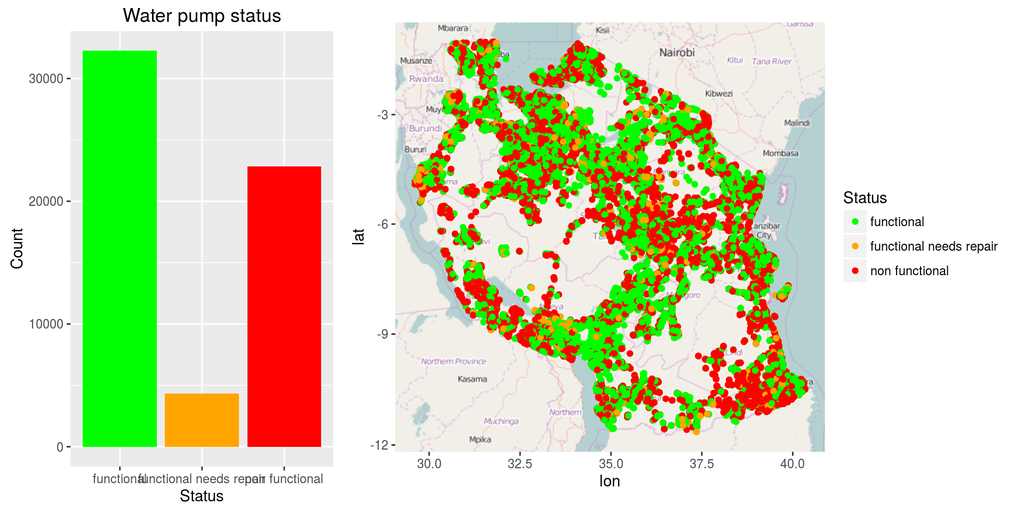

Here we can see two things:

- first, classes are imbalanced, there are far less ‘need repair’ than other classes
- second, the map seems to indicate that geographic position has an importance on the pump status

## H2O

### Pre-requisites

- R
- Java: JRE at least 1.6 (1.7 recommended)

### H2O Installation from R

The following command wil install latest version of H2O:

```r
install.packages("h2o", type = "source", repos = (c("http://h2o-release.s3.amazonaws.com/h2o/rel-tibshirani/8/R")))
```

### Your first instance

Starting a local instance is quite simple:

```r
library(h2o)
localH2O <- h2o.init()
```

```
##
## H2O is not running yet, starting it now...
##
## Note:  In case of errors look at the following log files:
##     /tmp/RtmpfR9qxt/h2o_geraud_started_from_r.out
##     /tmp/RtmpfR9qxt/h2o_geraud_started_from_r.err
##
##
## ..Successfully connected to http://127.0.0.1:54321/
##
## R is connected to the H2O cluster:
##     H2O cluster uptime:         2 seconds 474 milliseconds
##     H2O cluster version:        3.6.0.8
##     H2O cluster name:           H2O_started_from_R_geraud_nam887
##     H2O cluster total nodes:    1
##     H2O cluster total memory:   3.46 GB
##     H2O cluster total cores:    4
##     H2O cluster allowed cores:  2
##     H2O cluster healthy:        TRUE
##
## Note:  As started, H2O is limited to the CRAN default of 2 CPUs.
##        Shut down and restart H2O as shown below to use all your CPUs.
##            > h2o.shutdown()
##            > h2o.init(nthreads = -1)
```

You can also configure some extra parameters like RAM, thread number:

```r
localH2O <- h2o.init(nthreads = 12, max_mem_size = '24G')
```

This will start a local instance running on 12 threads and 24GB RAM. There are also option to connect on remote cluster.

### Loading data into H2O

```r
trainset.hex <- h2o.uploadFile(path = 'trainset_values.csv', destination_frame = 'trainset.hex', sep = ',', header = TRUE)
labels.hex <- h2o.uploadFile(path = 'trainset_labels.csv', destination_frame = 'labels.hex', sep = ',', header = TRUE)
trainsetFull.hex <- h2o.merge(trainset.hex, labels.hex)
```

Data should be loaded in H2O now, we can try a few commands:

```r
head(trainsetFull.hex)
```

```
##      id amount_tsh date_recorded              funder gps_height
## 1 69572       6000  1.300057e+12               Roman       1390
## 2  8776          0  1.362524e+12             Grumeti       1399
## 3 34310         25  1.361747e+12        Lottery Club        686
## 4 67743          0  1.359328e+12              Unicef        263
## 5 19728          0  1.310508e+12         Action In A          0
## 6  9944         20  1.299971e+12 Mkinga Distric Coun          0
##      installer longitude   latitude             wpt_name num_private
## 1        Roman  34.93809  -9.856322                 none           0
## 2      GRUMETI  34.69877  -2.147466             Zahanati           0
## 3 World vision  37.46066  -3.821329          Kwa Mahundi           0
## 4       UNICEF  38.48616 -11.155298 Zahanati Ya Nanyumbu           0
## 5      Artisan  31.13085  -1.825359              Shuleni           0
## 6          DWE  39.17280  -4.765587               Tajiri           0
##                     basin  subvillage  region region_code district_code
```

[output cut: 55 more lines]

```r
summary(trainsetFull.hex)
```

```
##  id              amount_tsh         date_recorded
##  Min.   :    0   Min.   :     0.0
##  1st Qu.:18488   1st Qu.:     0.0
##  Median :37050   Median :     0.0
##  Mean   :37115   Mean   :   317.7
##  3rd Qu.:55612   3rd Qu.:     0.0
##  Max.   :74247   Max.   :350000.0
##
##  funder                       gps_height         installer
##  Government Of Tanzania:9084  Min.   : -90.000   DWE       :17402
##  Danida                :3114  1st Qu.:  -1.309   Government: 1825
##  Hesawa                :2202  Median : 367.760   RWE       : 1206
##  Rwssp                 :1374  Mean   : 668.297   Commu     : 1060
##  World Bank            :1349  3rd Qu.:1317.612   DANIDA    : 1050
##  Kkkt                  :1287  Max.   :2770.000   KKKT      :  898
##  NA                    :4412                     NA        : 4432
##  longitude       latitude             wpt_name        num_private
##  Min.   : 0.00   Min.   :-1.165e+01   none     :3563  Min.   :   0.0000
##  1st Qu.:33.08   1st Qu.:-8.551e+00   Shuleni  :1748  1st Qu.:   0.0000
##  Median :34.90   Median :-5.033e+00   Zahanati : 830  Median :   0.0000
##  Mean   :34.08   Mean   :-5.706e+00   Msikitini: 535  Mean   :   0.4741
##  3rd Qu.:37.16   3rd Qu.:-3.332e+00   Kanisani : 323  3rd Qu.:   0.0000
##  Max.   :40.35   Max.   :-2.000e-08   Bombani  : 271  Max.   :1776.0000
##
##  basin                  subvillage    region            region_code
##  Lake Victoria  :10248  Madukani:508  Iringa     :5294  Min.   : 1.0
##  Pangani        : 8940  Shuleni :506  Shinyanga  :4982  1st Qu.: 5.0
##  Rufiji         : 7976  Majengo :502  Mbeya      :4639  Median :12.0
##  Internal       : 7785  Kati    :373  Kilimanjaro:4379  Mean   :15.3
##  Lake Tanganyika: 6432  Mtakuja :262  Morogoro   :4006  3rd Qu.:17.0
##  Wami / Ruvu    : 5987  Sokoni  :232  Arusha     :3350  Max.   :99.0
##                         NA      :371
##  district_code   lga                ward           population
##  Min.   : 0.00   Njombe      :2503  Igosi    :307  Min.   :    0.0
##  1st Qu.: 2.00   Arusha Rural:1252  Imalinyi :252  1st Qu.:    0.0
##  Median : 3.00   Moshi Rural :1251  Siha Kati:232  Median :    0.0
##  Mean   : 5.63   Bariadi     :1177  Mdandu   :231  Mean   :  179.9
##  3rd Qu.: 5.00   Rungwe      :1106  Nduruma  :217  3rd Qu.:  213.5
##  Max.   :80.00   Kilosa      :1094  Kitunda  :203  Max.   :30500.0
##
```

[output cut: 57 more lines]

```
##  communal standpipe         :28522  communal standpipe:34625
##  hand pump                  :17488  hand pump         :17488
##  other                      : 6380  other             : 6380
##  communal standpipe multiple: 6103  improved spring   :  784
##  improved spring            :  784  cattle trough     :  116
##  cattle trough              :  116  dam               :    7
##
##  status_group
##  functional             :32259
##  non functional         :22824
##  functional needs repair: 4317
##
##
##
##
```

### Machine Learning

Let’s split the data to validate our model:

```r
splits <- h2o.splitFrame(trainsetFull.hex, 0.8)
train <- splits[[1]]
test <- splits[[2]]

dim(train)
```

```
## [1] 47563    41
```

```r
dim(test)
```

```
## [1] 11837    41
```

Now we’ll check label proportion:

```r
prop.table(table(as.vector(train$status_group)))
```

```
##
##              functional functional needs repair          non functional
##              0.54435170              0.07129491              0.38435338
```

```r
prop.table(table(as.vector(test$status_group)))
```

```
##
##              functional functional needs repair          non functional
##              0.53797415              0.07822928              0.38379657
```

We will restrict the list of predictors as some nominal values contain lots of categories (‘wpt_name’, ‘subvillage’, ‘scheme_name’, ‘installer’, ‘ward’, ‘funder’):

```r
allVariables <- colnames(train)
predictors <- colnames(train)[!(allVariables %in% c('id', 'wpt_name', 'subvillage', 'scheme_name', 'installer', 'ward', 'funder', 'status_group', 'recorded_by'))]
```

Now we are going to train our random forest on the dataset:

```r
rfModel <- h2o.randomForest(predictors, 'status_group', train)
```

Let’s validate it:

```r
confusionMatrix <- h2o.confusionMatrix(rfModel, newdata = test)

# Render table
library(knitr)
kable(confusionMatrix)
```

|  | functional | functional needs repair | non functional | Error | Rate |
| --- | --- | --- | --- | --- | --- |
| functional | 5772 | 99 | 497 | 0.0935930 | 596 / 6,368 |
| functional needs repair | 545 | 247 | 134 | 0.7332613 | 679 / 926 |
| non functional | 1031 | 40 | 3472 | 0.2357473 | 1,071 / 4,543 |
| Totals | 7348 | 386 | 4103 | 0.1981921 | 2,346 / 11,837 |

### Shutting down

```r
h2o.shutdown(prompt = FALSE)
```

```
## [1] TRUE
```